# carx:an R Package to Estimate Censored Autoregressive Time Series with Exogenous Covariates

The `plot()` function provides a visual check of how the fitted values track the data, with the censoring limits superimposed on the diagram, see Figure 2.

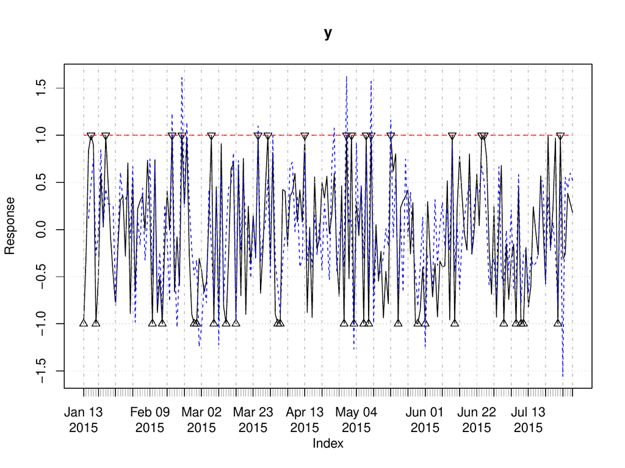

Figure 2: Time plot of the raw data and fitted values from the CARX model. The observed responses are connected as a solid black line, and the lower and upper censoring limits drawn as red dotted and dashed line with censored observations marked by triangles pointing up and down, respectively. The fitted values are connected as a blue dashed line.

```r
> plot(modelSim)
```

Model diagnostics are facilitated by the `tsdiag()` function which is similar to the `tsdiag()` function in [*TSA*](https://CRAN.R-project.org/package=TSA) package (Chan and Ripley 2012). The `tsdiag()` function generates a plot of 4 sub-figures, namely, the time plot of the simulated residuals which is useful for visually checking the presence of residual temporal patterns and/or outliers, the simulated residuals versus fitted values plot which is useful for checking the adequacy of the linear regression model assumptiom, the residual autocorrelation function (ACF) plot that quantifies the residual correlations, and the plot of the p-values of the Ljung-Box tests for the presence of residual autocorrelation. The following command generates the diagnostics plot for the model fitted to the simulated data.

```r
> tsdiag(modelSim)
```

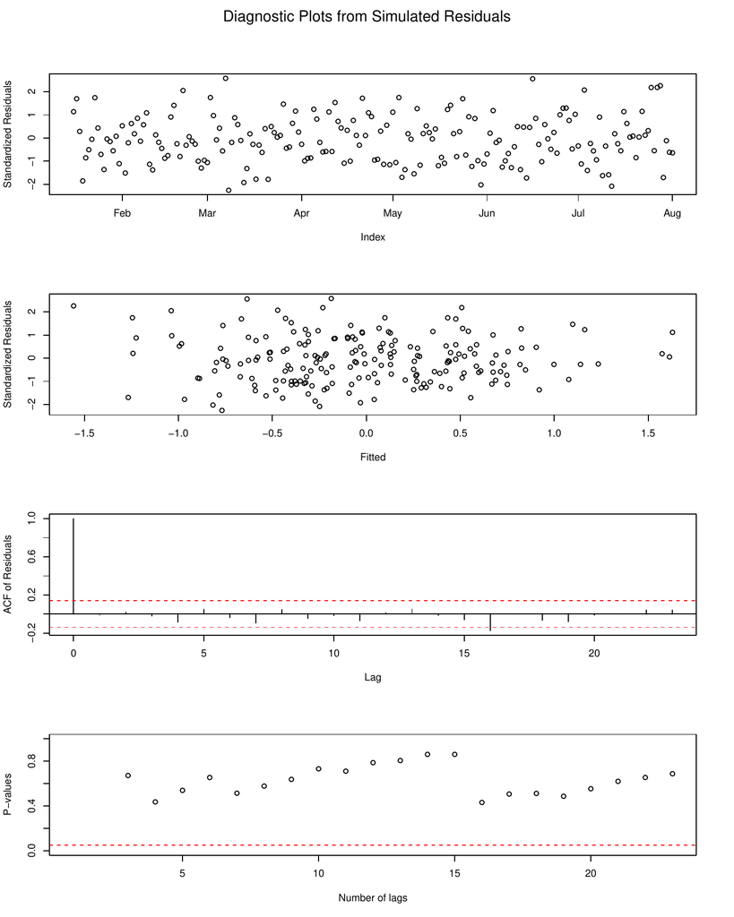

Figure 3: Diagnostic plots based on simulated residuals.

## A real data application

In this example we utilize the package to analyze the change of total phosphorus (P) concentrations in river water. Phosphorus is a major nutrient in river water, of which an excessive amount can result in environmental problem such as eutrophication. Phosphorus concentration in many rivers in Iowa has been monitored under the ambient water quality program conducted by the Iowa Department of Natural Resources (Libra, Wolter, and Langel 2004). An analysis of the change of P concentration has been reported by (Wang, Chan, and Schilling 2016). Here we illustrate the analysis for a particular data set from an ambient site located in the West Fork Cedar River at Finchford, with the data available in a `"cenTS"` object named `pts` in the *carx* package.

The P concentrations (in mg/l) were left-censored whenever they fell below certain time-varying detection limits, resulting in a censoring rate of $12.6\%.$ The data were collected monthly from October 1998 to October 2013, but data collection was suspended between September 2008 to March 2009, owing to lack of funding. In the data set, there are serveral variables.

```r
> names(pts)

[1] "logP"     "lcl"      "ci"       "tInMonth" "logQ"     "season"
```

The variable `logP` consists of the logarithmic P, `lcl` the corresponding censoring limits, `ci` the indicator variable of censoring, `tInMonth` is the time index (in month), `logQ` is the corresponding logarithmic water discharge data (Q) measured in cf/s, obtained from the U.S. Geological Survey, and season indicates to which `season` the month index belongs (see below for further details). P is generally correlated with the water discharge (Schilling et al. 2010). We will explore the relationship between P and Q. See Figure 4 for the time plots of P, Q, and the historical censoring limits.

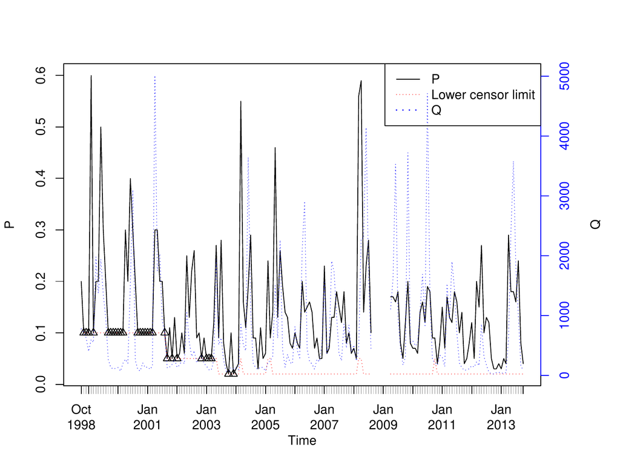

Figure 4: Time series plots of P (black line, scale shown on the left vertical axis), Q (blue line, scale shown on the right vertical axis) and the censor limits $l_t$ (red line, in the same scale as that of P). Censored observations are marked by triangles.

It is also conjectured that the association between the logP and logQ may be seasonal. The variable `season` in `pts` is constructed to denote the quarter of the month with Quarter 1 consists of the first three months, namely, January, February, and March; Quarter 2 comprises the next three months, and so on. Figure 5 illustrates the seasonal relationship between `logP` and `logQ`. It is of interest whether there exists a linear trend in the logarithmic P. Preliminary analysis (not reported here) suggests the presence of significant autocorrelation in the regression errors. Thus, the general model takes the following form
$$\begin{aligned}
\log\left(P_t\right) = \beta_1 t+ f\left(\log\left(Q_t\right)\right) +
\eta_t,
\end{aligned}$$
where $f$ is some linear function that may be seasonal in the intercept and/or seasonal in the coefficient of `logQ`, and $\eta_t$ follows an AR process.

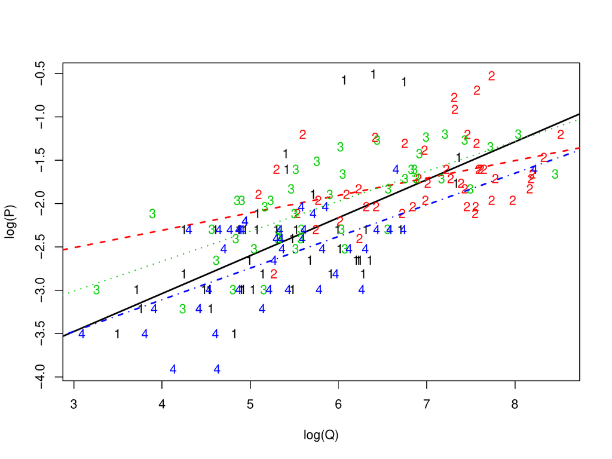

Figure 5: Scatter plot of `logP` versus `logQ`. The data are labeled by different numbers (1 for Quarter 1 and so on) and colors (black, red, green, blue for Quarter 1, 2, 3 and 4, respectively). Least squares quaterly regression lines (solid, dashed, dotted, and dash dotted) are superimposed with the same color as the data points.

Note that we need to determine whether the intercept and/or the regression coefficient are seasonal, and whether to include in the model a time trend, resulting in 8 combinations. Moreover, the AR order for the regression errors has to be specified. Assuming the maximal AR order to be $m$, we have to select among $8\times m$ models, which can be done by selecting the best model that achieves the smallest AIC. Model selection by AIC is automated by the function `carxSelect()`. Here, the maximal AR order is 3.

```r
> arOrder <- 3
```

The list of models, named `M1` to `M8`, is specified in the following code.

```r
> s1 <- logP ~ logQ
> s2 <- logP ~ tInMonth + logQ
> s3 <- logP ~ logQ:as.factor(season)
> s4 <- logP ~ tInMonth + logQ:as.factor(season)
> s5 <- logP ~ as.factor(season) + logQ - 1
> s6 <- logP ~ tInMonth + as.factor(season) + logQ - 1
> s7 <- logP ~ as.factor(season) + logQ:as.factor(season) - 1
> s8 <- logP ~ tInMonth + as.factor(season) +  logQ:as.factor(season) - 1
> fmls <- c(s1,s2,s3,s4,s5,s6,s7,s8)
> names(fmls) <- paste0('M',seq(1,8))
```

The model selection is performed by invoking the function `carxSelect()` which has two required arguments: a list of formulas and the maximal AR orders, plus an optional argument `detect.outlier`, which by default is `TRUE`, indicates whether outliers should be detected in the model. The function `carxSelect()` returns a `"carx"` object comprising an additional element `selectionInfo` which is a list containing more information about the selection result, including `aicMat` which is a matrix whose $(i,j)$th element is the AIC of the model represented by the $i^{th}$ formula in the list and AR order $j$.

For the purpose of illustrating the prediction by the `predict()` method, we use all data up to the end of 2012 for model selection and fitting, and then check the model prediction against the observed data in 2013.

```r
> cs <- carxSelect(fmls, arOrder, data = pts['1998/2012'],
+                  detect.outlier = TRUE, CI.compute = TRUE)
> print(round(cs$selectionInfo$aicMat,1))

     AR1   AR2   AR3
M1 -41.8 -39.6 -38.2
M2 -39.7 -38.1 -36.8
M3 -51.2 -47.5 -45.1
M4 -49.4 -45.9 -43.6
M5 -53.2 -49.6 -47.1
M6 -51.5 -48.2 -45.8
M7 -53.9 -50.8 -47.6
M8 -52.8 -49.8 -46.8
```

A summary of the model fit is shown below.

```r
> summary(cs)

Call:
carx.formula(formula = formula(m0), data = m0$data, p = m0$p,
    CI.compute = ..1)


Coefficients:
                         Estimate    StdErr   lowerCI upperCI p.value
as.factor(season)1      -6.053239  0.633190 -7.325537 -4.9191  <2e-16 ***
as.factor(season)2      -3.455734  0.612764 -4.696565 -2.2607  <2e-16 ***
as.factor(season)3      -4.235837  0.414149 -5.028568 -3.4297  <2e-16 ***
as.factor(season)4      -4.854407  0.476015 -5.764154 -3.9324  <2e-16 ***
as.factor(season)1:logQ  0.633582  0.111002  0.436431  0.8566  <2e-16 ***
as.factor(season)2:logQ  0.248797  0.086893  0.073705  0.4247   0.006 **
as.factor(season)3:logQ  0.373538  0.068555  0.235532  0.5053  <2e-16 ***
as.factor(season)4:logQ  0.389721  0.087467  0.217672  0.5584  <2e-16 ***
AR1                      0.075072  0.090671 -0.137839  0.2227   0.596
sigma                    0.482897  0.028770  0.412907  0.5265  <2e-16 ***
---
Signif. codes:  0 ‘***’ 0.001 ‘**’ 0.01 ‘*’ 0.05 ‘.’ 0.1 ‘ ’ 1

AIC:
[1] -53.85639
```

The fitted model can be visualized by calling the `plot()` function, which is shown in Figure 6. The fitted values appear to track the data well.

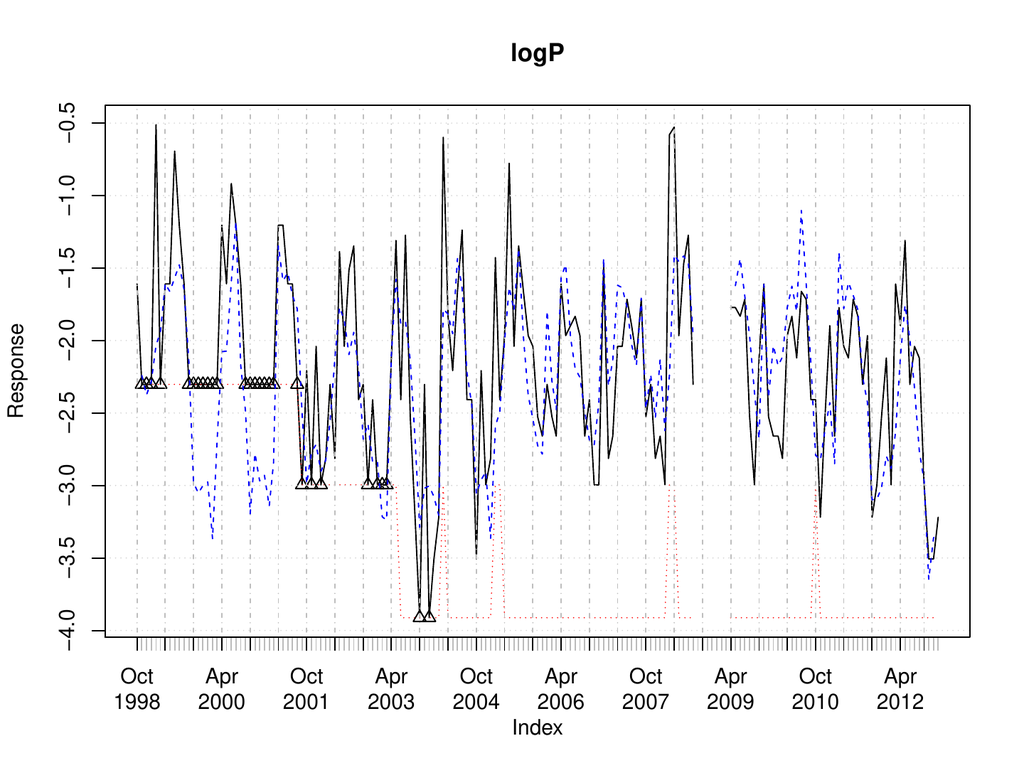

Figure 6: Time plot of the raw data and fitted values from the CARX model. The observed responses are connected as a solid black line, and the lower censoring limits drawn as a red dotted line with censored observations marked by triangles pointing up . The fitted values are connected as a blue dashed line. Outliers (if detected) are marked with a dashed red vertical line.

```r
> plot(cs)
```

We examine the goodness-of-fit of the fitted model via the `tsdiag()` function which generates 4 diagnostic plots in Figure 7. These plots indicate that the fitted model provides good fit to the data.

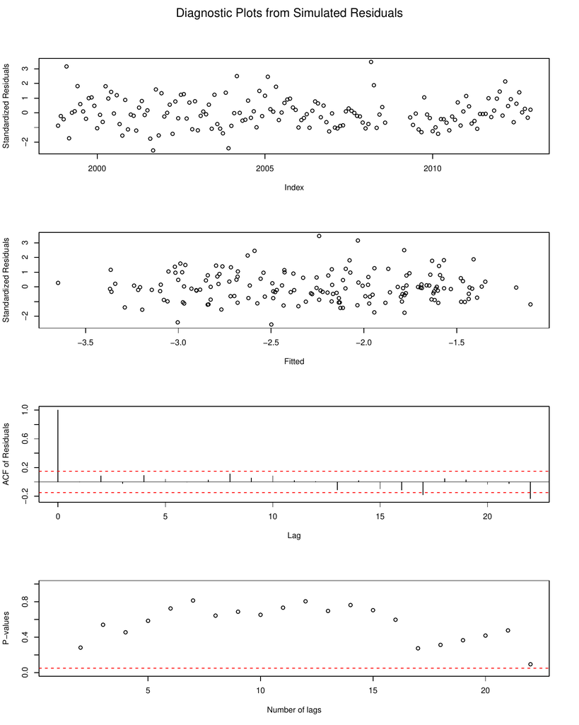

Figure 7: Model diagnostic plots. The plots from top to bottom correspond respectively to the time series plots of standadized simulated residuals, residuals versus fitted values, the residual autocorrelation plots, and the Ljung-Box test statistics of the residuals.

```r
> tsdiag(cs)
```

The selected model can be interpreted as follows. The linear trend was not selected, suggesting no significant long-term change in the P concentrations. The intercept and the regression coefficient of logQ were seasonal. The regression errors appeared to be mildly auto-correlated and can be modeled as an order 1 AR process, although the AR coefficient was not significant.

Finally, we compute the prediction of `logP` via the `predict()` method and compare the prediction with the actual data from January to October 2013. Note the prediction makes use of observed discharge data in 2013. Figure 8 shows the point predictors (blue dashed line) against the actual values (black solid line) and the 95% prediction bands (red lines), which indicates that the prediction tracks the actual data well.

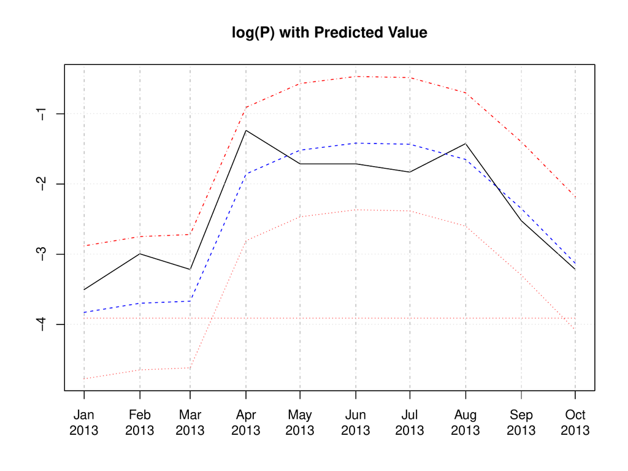

Figure 8: Plot of predictions and observed values. The observed values are drawn by black solid line. The predicted values, lower and upper bound of confidence intervals are drawn by blue dashed, red dotted, and red dash dotted lines respectively.

# A simulation study on model selection

In this section, we report a simulation study on the effectiveness of model selection by minimizing the AIC. Recall this functionality is implemented by the `carxSelect()` function which outputs the model with the smallest AIC from a set of models of various AR orders up to some pre-specified maximum order.

We restrict the simulation study to the problem of selecting the AR order with the same model specification, i.e, the same set of regressors, which is conducted as follows. We simulated 1000 series by calling `carxSim()` with the default setting, hence the true AR order is equal to 2, and for each simulated series we selected the best model among the models with the AR order from 1 to 6. Since the uncensored data were available in the simulation, we repeated the model selection with the uncensored observed data, for comparing with the results using the censored data. This simulation study can be reproduced by the following code.

```r
> singleTestSelectAROrder <- function(iter)
+ {
+   seed <- 1375911
+   cts <- carxSim(seed = iter*seed)
+   m0 <- carxSelect(list(f1 = as.formula(y~X1+X2-1)), max.ar = 6,
+                    data=cts[,c("y","X1","X2")],detect.outlier = FALSE)
+   m1 <- carxSelect(list(f1 = as.formula(y~X1+X2-1)),max.ar = 6,
+                    data = cts, detect.outlier = FALSE)
+   c(m0$fitted$p, m1$fitted$p)
+ }
> nRep <- 1000
> orders <- parallel::mclapply( 1:nRep, singleTestSelectAROrder,
+           mc.cores = parallel::detectCores() - 1)
> orders <- do.call(rbind, lapply(orders, matrix, ncol = 2, byrow = TRUE))
> freqComDat = count(orders[1,])
> freqCenDat = count(orders[2,])
```

The selected orders are reported in Table 1, which shows that the true order can be recovered with an empirical probability of $52.7\%$, and the results using censored and complete data are comparable.

Table 1: Summary of selected orders. The frequency of selected orders with complete data and censored data are reported.

| AR order | 1 | 2 | 3 | 4 | 5 | 6 |
| --- | --- | --- | --- | --- | --- | --- |
| Frequency (complete data) | 17 | 626 | 139 | 97 | 69 | 52 |
| Frequency (censored data) | 37 | 527 | 160 | 99 | 101 | 76 |

# Performance of model prediction

In this section we report a simulation study about the empirical performance of the model prediction procedure. A series of 210 data was simulated using the default parameters of `carxSim()`, with the first 200 data used to estimate the model, and the last 10 observations used to compare with the predicted values based on the fitted model and the simulated future covariate values. The above procedure was repeated 500 times. The empirical coverage rates of the 95% $\ell$-step ahead prediction intervals, $\ell=1,2,\ldots,10$, are summarized in Table 2, which indicates a close match between the empirical and nominal coverage rates. The simulation exercise can be reproduced by the following code.

```r
> nRep = 500; nObs = 200; n.ahead=10
> runSimPredCR <- function()
+ {
+   set.seed(0)
+   crMat = matrix(nrow = n.ahead, ncol = nRep)
+   for(iRep in 1:nRep)
+   {
+     sdata = carxSim(nObs = nObs + n.ahead)
+     trainingData = sdata[1:nObs,]
+     testData = sdata[-(1:nObs),]
+     mdl = carx(y ~ X1 + X2 - 1, data = trainingData, p = 2)
+     newxreg = testData[,c('X1','X2')]
+     predVal = predict(mdl, newxreg = newxreg, n.ahead = n.ahead)
+     crInd = (predVal$ci[,1] <= testData$y) & (predVal$ci[,2] >= testData$y)
+     crMat[,iRep] = crInd
+   }
+   crPred = apply(crMat,1,mean)
+ }
> runSimPredCR()
```

Table 2: Empirical coverage rates of nominally 95% predictive confidence intervals for $\ell$-step-ahead prediction, for $\ell=1,2,\ldots, 10$.

| n.ahead | 1 | 2 | 3 | 4 | 5 | 6 | 7 | 8 | 9 | 10 |
| --- | --- | --- | --- | --- | --- | --- | --- | --- | --- | --- |
| Empirical Coverage | 0.954 | 0.932 | 0.946 | 0.952 | 0.946 | 0.946 | 0.938 | 0.946 | 0.948 | 0.952 |

# Conclusion

In summary, we have reviewed the quasi-likelihood method to estimate a censored time series regression model and introduced the *carx* package in which quasi-likelihood estimation is implemented, together with other useful functions for model selection, prediction, diagnostics and outlier detections. We illustrated the *carx* package with two major examples, and shed light on the effectiveness of model selection via minimizing AIC and the prediction accuracy.

Future work includes extending the method for more complex regression noise structure than the AR model, for instance, the more general ARIMA model, and updating the package according to the feedback from the public.

Buckley, Jonathan, and Ian James. 1979. “Linear Regression with Censored Data.” *Biometrika* 66 (3): 429–36. https://doi.org/10.1093/biomet/66.3.429.

Chan, Kung-Sik, and Brian Ripley. 2012. *TSA: Time Series Analysis*. https://CRAN.R-project.org/package=TSA.

Cryer, Jonathan D., and Kung Sik Chan. 2008. *Time Series Analysis: With Applications in r*. New York: Springer-Verlag. https://doi.org/10.1007/978-0-387-75959-3.

Genz, Alan, Frank Bretz, Tetsuhisa Miwa, Xuefei Mi, and Torsten Hothorn. 2017. *Mvtnorm: Multivariate Normal and t Distributions*. https://CRAN.R-project.org/package=mvtnorm.

Gourieroux, Christian, Alain Monfort, Eric Renault, and Alain Trognon. 1987. “Simulated Residuals.” *Journal of Econometrics* 34 (1): 201–52. https://doi.org/10.1016/0304-4076(87)90073-X.

Henningsen, Arne. 2010. “Estimating Censored Regression Models in R Using the censReg Package.” *University of Copenhagen*.

———. 2013. *censReg: Censored Regression (Tobit) Models*. http://CRAN.R-project.org/package=censReg.

Huang, Jian, and A. J. Rossini. 1997. “Sieve Estimation for the Proportional-Odds Failure-Time Regression Model with Interval Censoring.” *Journal of the American Statistical Association* 92 (439): 960–67. https://doi.org/10.1080/01621459.1997.10474050.

Kleiber, Christian, and Achim Zeileis. 2008. *Applied Econometrics with R*. New York: Springer-Verlag. https://doi.org/10.1007/978-0-387-77318-6.

Konishi, Sadanori, and Genshiro Kitagawa. 2008. *Information Criteria and Statistical Modeling*. Springer-Verlag. https://doi.org/10.1007/978-0-387-71887-3.

Lee, Lopaka. 2013. *NADA: Nondetects and Data Analysis for Environmental Data*. http://CRAN.R-project.org/package=NADA.

Libra, Robert D, Calvin F Wolter, and Richard John Langel. 2004. *Nitrogen and Phosphorus Budgets for Iowa and Iowa Watersheds*. Iowa Department of Natural Resources, Geological Survey.

Martin, Andrew D., Kevin M. Quinn, and Jong Hee Park. 2011. “MCMCpack: Markov Chain Monte Carlo in R.” *Journal of Statistical Software* 42 (9): 22. https://doi.org/10.18637/jss.v042.i09.

McLeod, A. I., Nagham M. Mohammad, Justin Veenstra, and Abdel El-Shaarawi. 2014. *cents: Censored Time Series*. http://CRAN.R-project.org/package=cents.

Park, Jung Wook, Marc G. Genton, and Sujit K. Ghosh. 2007. “Censored Time Series Analysis with Autoregressive Moving Average Models.” *Canadian Journal of Statistics* 35 (1): 151–68. https://doi.org/10.1002/cjs.5550350113.

Ryan, Jeffrey A., and Joshua M. Ulrich. 2017. *xts: eXtensible Time Series*. https://CRAN.R-project.org/package=xts.

Schilling, Keith E, Kung Sik Chan, Hai Liu, and You Kuan Zhang. 2010. “Quantifying the Effect of Land Use Land Cover Change on Increasing Discharge in the Upper Mississippi River.” *Journal of Hydrology* 387 (3): 343–45. https://doi.org/10.1016/j.jhydrol.2010.04.019.

Schumacher, Fernanda L., Victor H. Lachos, and Christian E. Galarza. 2016. *ARCensReg: Fitting Univariate Censored Linear Regression Model with Autoregressive Errors*. http://CRAN.R-project.org/package=ARCensReg.

Tallis, G. M. 1961. “The Moment Generating Function of the Truncated Multi-Normal Distribution.” *Journal of the Royal Statistical Society B* 23 (1): 223–29.

Tobin, James. 1958. “Estimation of Relationships for Limited Dependent Variables.” *Econometrica: Journal of the Econometric Society*, 24–36. https://doi.org/10.2307/1907382.

Wang, Chao, and Kung-Sik Chan. 2017a. *Carx: Censored Autoregressive Model with Exogenous Covariates*. https://CRAN.R-project.org/package=carx.

———. 2017b. “Quasi-Likelihood Estimation of a Censored Autoregressive Model with Exogenous Variables.” *Journal of the American Statistical Association*. https://doi.org/10.1080/01621459.2017.1307115.

Wang, Chao, Kung-Sik Chan, and Keith E Schilling. 2016. “Total Phosphorus Concentration Trends in 40 Iowa Rivers, 1999 to 2013.” *Journal of Environmental Quality*. https://doi.org/10.2134/jeq2015.07.0365.

Yee, Thomas W. 2015. *Vector Generalized Linear and Additive Models*. Springer-Verlag. https://doi.org/10.1007/978-1-4939-2818-7.

Zeger, Scott L., and Ron Brookmeyer. 1986. “Regression Analsis with Censored Autocorrelated Data.” *Journal of the American Statistical Association* 81 (395): 722–29. https://doi.org/10.1080/01621459.1986.10478328.